# HW4-ADA

# Jing Qian (jq2282)

##### 1.a. Complete the table.

From the description, we have $a=2,\ b=3,\ n=3$. So the table is as following:

| Source | df | SS | MS | F |
| --- | --- | --- | --- | --- |
| Popper (A) | 1 | 4.5 | 4.5 | 32.374 |
| Corn (B) | 2 | 15.75 | 7.875 | 56.655 |
| Interaction (A*B) | 2 | 0.08 | 0.04 | 0.288 |
| Error | 12 | 1.67 | 0.139 | 1 |
| Total | 17 | 22.00 |  |  |

##### 1.b. Test H0 : No interaction against H1 : there is an interaction, use $\alpha$ = 0.05.

If $F=\frac{MSAB}{MSE}>F_{\alpha}((a-1)(b-1), ab(n-1))$, we could reject $H_0$.

```r
qf(1-0.05, df1=2, df2=12)
```

```
[1] 3.885294
```

From above, $F=0.288$ while $F_{0.05}(2,12) = 3.885,\ F<F_{0.05}(2,12)$. So we could not reject $H_0$ and there is no interaction.

##### 1.c/d. Complete the table.

| Source | df | SS | MS | F |
| --- | --- | --- | --- | --- |
| Popper (A) | 1 | 4.5 | 4.5 | 36 |
| Corn (B) | 2 | 15.75 | 7.875 | 63 |
| Error | 14 | 1.75 | 0.125 | 1 |
| Total | 17 | 22.00 |  |  |

##### 1.e. Test H0 : No popper effect against H1 : there is a popper effect. use $\alpha$ = 0.05.

Since there is no interaction between A and B, if $F=\frac{MSA}{MSE}>F_{\alpha}(1, 14)$, we could reject $H_0$. From above, $F=36$ while $F_{0.05}(1,14) = 4.6,\ F>F_{0.05}(1, 14)$. So we could reject $H_0$ and conclude that there is a popper effect.

##### 1.f. Test H0 : No corn effect against H1 : there is a corn effect. use $\alpha$ = 0.05.

Since there is no interaction between A and B, if $F=\frac{MSB}{MSE}>F_{\alpha}(2, 14)$, we could reject $H_0$. From above, $F=63$ while $F_{0.05}(2,14) = 3.74,\ F>F_{0.05}(2, 14)$. So we could reject $H_0$ and conclude that there is a corn effect.

##### 2.a. Construct an interaction plot.

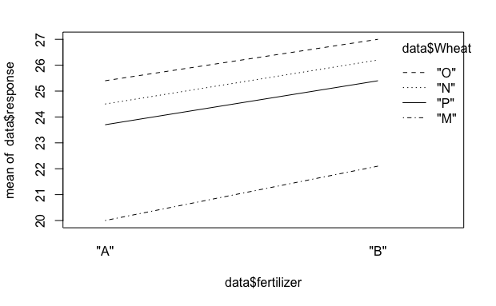

```r
data<-read.csv('~/Desktop/AdvancedDA/HW/HW4/HW4DATA.csv', header=TRUE)
interaction.plot(data$fertilizer,data$Wheat,data$response)
```

From the interaction plot above, we could see that the four lines seem to be parallel which suggests that there is no interaction between fertilizer type and wheat type.

##### 2.b. Test H0 : No interaction against H1 : there is an interaction, use $\alpha$ = 0.05.

```r
summary(aov(data$response~data$fertilizer*data$Wheat))
```

```
                           Df Sum Sq Mean Sq F value   Pr(>F)
data$fertilizer             1  18.90  18.904   48.63 3.14e-06 ***
data$Wheat                  3  92.02  30.674   78.90 8.37e-10 ***
data$fertilizer:data$Wheat  3   0.22   0.074    0.19    0.902
Residuals                  16   6.22   0.389
---
Signif. codes:  0 ‘***’ 0.001 ‘**’ 0.01 ‘*’ 0.05 ‘.’ 0.1 ‘ ’ 1
```

In the above ANOVA table, we could see that Pr(>F) for interaction is 0.902, which is larger than $\alpha=0.05$. So we could not reject $H_0$ and there is no interaction between fertilizer and wheat effects.

##### 2.c. Fit a model without an interaction and test H0 : No fertilizer effect against H1 : there is a fertilizer effect. Use $\alpha$ = 0.05 if you reject H0, use Tukey’s method to do pairwise comparisons of the different fertilizer types.

```r
summary(aov(data$response~data$fertilizer+data$Wheat))
```

```
                Df Sum Sq Mean Sq F value   Pr(>F)
data$fertilizer  1  18.90  18.904   55.76 4.59e-07 ***
data$Wheat       3  92.02  30.674   90.48 1.97e-11 ***
Residuals       19   6.44   0.339
---
Signif. codes:  0 ‘***’ 0.001 ‘**’ 0.01 ‘*’ 0.05 ‘.’ 0.1 ‘ ’ 1
```

From the above ANOVA table for model without interactions, we could see that Pr(>F) for fertilizer is 4.59e-07, which is smaller than $\alpha=0.05$. So we could reject $H_0$ and there is a fertilizer effect.

```r
fit<-aov(data$response~data$fertilizer+data$Wheat)
TukeyHSD(fit, "data$fertilizer")
```

```
  Tukey multiple comparisons of means
    95% family-wise confidence level

Fit: aov(formula = data$response ~ data$fertilizer + data$Wheat)

$`data$fertilizer`
         diff      lwr      upr p adj
"B"-"A" 1.775 1.277484 2.272516 5e-07
```

In the above, we use Tukey’s method to do pairwise comparisons of different fertilizer types. We could see that the 95% confidence interval for B-A is [1.277484, 2.272516], which doesn’t cover 0. So there is fertilizer effect and fertilizer B leads to more yields than A.

##### 2.d. Test H0 : No wheat effect against H1 : there is a wheat effect. Use $\alpha$ = 0.05 if you reject H0, use Tukey’s method to do pairwise comparisons of the different wheat types.

From the ANOVA table in 2.c., we could find that Pr(>F) for wheat is 1.97e-11, which is smaller than $\alpha=0.05$. So we could reject $H_0$ and there is a wheat effect.

```r
TukeyHSD(fit, "data$Wheat")
```

```
  Tukey multiple comparisons of means
    95% family-wise confidence level

Fit: aov(formula = data$response ~ data$fertilizer + data$Wheat)

$`data$Wheat`
         diff         lwr        upr     p adj
"N"-"M"  4.30  3.35476633  5.2452337 0.0000000
"O"-"M"  5.15  4.20476633  6.0952337 0.0000000
"P"-"M"  3.50  2.55476633  4.4452337 0.0000000
"O"-"N"  0.85 -0.09523367  1.7952337 0.0872269
"P"-"N" -0.80 -1.74523367  0.1452337 0.1152696
"P"-"O" -1.65 -2.59523367 -0.7047663 0.0005208
```

Using Tukey’s method to do pairwise comparisons of the different wheat types, we could find that M is a separate group which has lower yields than N, O and P. It is impossible to set up consistent groups for N, O and P: O and N are not significantly different; P and N are not significantly different; but P has lower yields than O.